# RQ Answers

omitted

2024-04-05

```r
glimpse(all_data)
```

```
## Rows: 175,667
## Columns: 11
## $ repo                <chr> "accumulo", "accumulo", "accumulo", "accumulo", "a…
## $ pr_number           <int> 1302, 1302, 1302, 1302, 1302, 1302, 1302, 1302, 13…
## $ rule                <chr> "java:S1192", "java:S3776", "java:S1319", "java:S1…
## $ severity            <chr> "CRITICAL", "CRITICAL", "MINOR", "CRITICAL", "CRIT…
## $ file                <chr> "core/src/main/java/org/apache/accumulo/core/metad…
## $ type                <chr> "CODE_SMELL", "CODE_SMELL", "CODE_SMELL", "CODE_SM…
## $ status              <chr> "OPEN", "OPEN", "OPEN", "OPEN", "CLOSED", "OPEN", …
## $ debt                <int> 8, 6, 10, 5, 6, 2, 5, 15, 30, 109, 30, 30, 5, 5, 5…
## $ ncloc_affected_file <int> 347, 347, 347, 347, 347, 347, 347, 347, 252, 252, …
## $ complexity          <int> 68, 68, 68, 68, 68, 68, 68, 68, 86, 86, 86, 86, 86…
## $ origin              <chr> "NEW", "NEW", "NEW", "NEW", "PRE-EXISTING", "PRE-E…
```

# RQ1

## TDD (Technical Debt Density) by PR Distribution

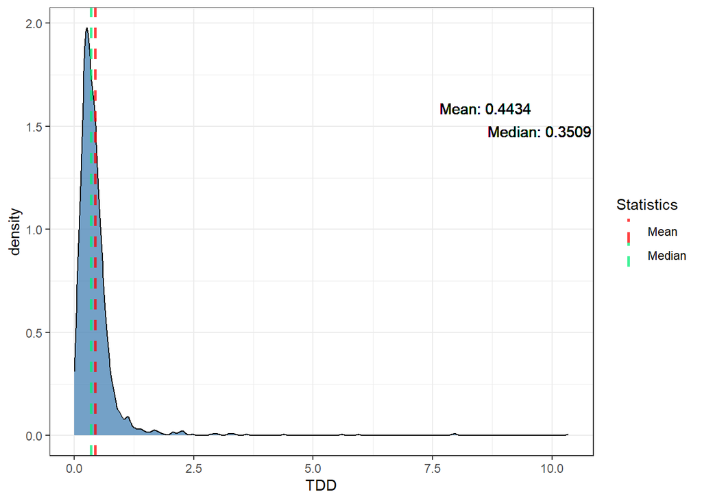

## TDV (Technical Debt Variation)

### TDV Distribution

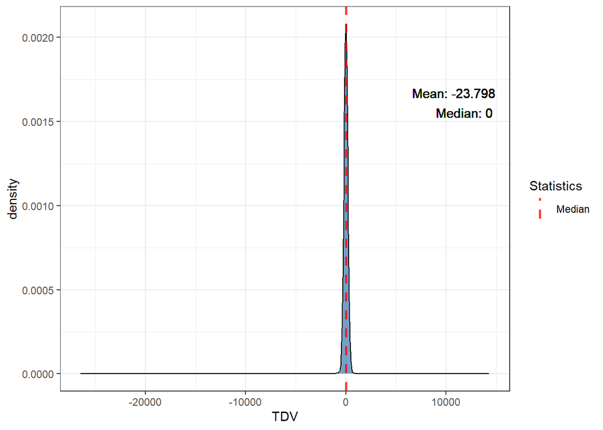

### Percentages for TDV < 0 (TD decrease), TDV = 0 (TD unchanged) and TDV > 0 (TD increased) by repo

```
## # A tibble: 12 × 4
##    repo              tdv_lower_than_zero tdv_equal_to_zero tdv_greater_than_zero
##    <chr>                           <dbl>             <dbl>                 <dbl>
##  1 accumulo                        26.5               53.4                 20.1
##  2 cayenne                         12.8               72.3                 14.9
##  3 commons-collecti…               35.3               64.7                  0
##  4 commons-io                      22                 72                    6
##  5 commons-lang                     9.68              89.2                  1.08
##  6 helix                           20                 44.9                 35.1
##  7 httpcomponents-c…               16.4               61.8                 21.8
##  8 maven-surefire                  20                 80                    0
##  9 opennlp                         44.6               44.6                 10.8
## 10 struts                          35.2               44.3                 20.5
## 11 wicket                          15.6               59.4                 25
## 12 zookeeper                       14.3               71.4                 14.3
```

### Mean of percentages of TDV (mean of repo percentages)

```
## # A tibble: 1 × 3
##   mean_tdv_lower_than_zero mean_tdv_equal_to_zero mean_tdv_greater_than_zero
##                      <dbl>                  <dbl>                      <dbl>
## 1                     22.7                   63.2                       14.1
```

### Percentages of pre-existing TDV by repo

```
## # A tibble: 12 × 3
##    repo                  preexisting_tdv_equal_to_zero preexisting_tdv_greater…¹
##    <chr>                                         <dbl>                     <dbl>
##  1 accumulo                                       62.7                     37.3
##  2 cayenne                                        80.8                     19.2
##  3 commons-collections                            58.8                     41.2
##  4 commons-io                                     76                       24
##  5 commons-lang                                   90.3                      9.68
##  6 helix                                          62.7                     37.3
##  7 httpcomponents-client                          75.7                     24.3
##  8 maven-surefire                                 80                       20
##  9 opennlp                                        42.5                     57.5
## 10 struts                                         55.4                     44.6
## 11 wicket                                         61.3                     38.7
## 12 zookeeper                                      78.6                     21.4
## # ℹ abbreviated name: ¹preexisting_tdv_greater_than_zero
```

## Mean of percentages of pre-existing TDV (mean of repo percentages)

```
## # A tibble: 1 × 2
##   preexisting_tdv_equal_to_zero mean_preexisting_tdv_greater_than_zero
##                           <dbl>                                  <dbl>
## 1                          68.7                                   31.3
```

### Percentages for new TDV by repo

```
## # A tibble: 12 × 3
## # Groups:   repo [12]
##    repo                  new_tdv_equal_to_zero new_tdv_greater_than_zero
##    <chr>                                 <dbl>                     <dbl>
##  1 accumulo                               73.2                     26.8
##  2 cayenne                                90                       10
##  3 commons-collections                     0                      100
##  4 commons-io                             77.8                     22.2
##  5 commons-lang                          100                        0
##  6 helix                                  72.4                     27.6
##  7 httpcomponents-client                  93.1                      6.9
##  8 maven-surefire                        100                        0
##  9 opennlp                                96.8                      3.23
## 10 struts                                 85.7                     14.3
## 11 wicket                                 88.9                     11.1
## 12 zookeeper                              85.7                     14.3
```

## Mean of percentages of new TDV (mean of repo percentages)

```
## # A tibble: 1 × 2
##   mean_new_tdv_equal_to_zero mean_new_tdv_greater_than_zero
##                        <dbl>                          <dbl>
## 1                       80.3                           19.7
```

## RQ2

As data is unbalanced across repositories, as shown in the issue characterization (../issues_characterization.Rmd), we will examine the top 10 fixed issues and the top 10 unfixed issues for each repository, and then aggregate them into a rank using the $PositionScore$ metric given by the following formula:

$PositionScore_{i} = \sum\limits_{j=1}^{k} Position_{j}$

given a rule $i$, its $PositionScore_{i}$ will be the sum of its position across all $k$ repositiries.After calculating the metrics for all rules, we rank them in a TOP 10 of the most frequent rules (fixed or unfixed, depending on the context) across repositories. The lower the PositionScore, the more frequent the rule across repositories.

### TOP 10 fixed per repo ranked by count

All top 10 fixed rules for each repo.

```
## # A tibble: 10 × 13
## # Groups:   rank [10]
##     rank accumulo      cayenne `commons-collections` `commons-io` `commons-lang`
##    <int> <chr>         <chr>   <chr>                 <chr>        <chr>
##  1     1 java:S117  -… java:S… java:S1125  -  8      java:S1125 … java:S3358  -…
##  2     2 java:S2589  … java:S… java:S1197  -  5      java:S1192 … java:S2293  -…
##  3     3 java:S112  -… java:S… java:S1612  -  2      java:S1612 … java:S1155  -…
##  4     4 java:S1125  … java:S… java:S1128  -  1      java:S1135 … java:S2326  -…
##  5     5 java:S101  -… java:S… java:S1192  -  1      java:S1066 … java:S1066  -…
##  6     6 java:S2293  … java:S… java:S2583  -  1      java:S3008 … java:S117  - …
##  7     7 java:S3776  … java:S… java:S1155  -  1      java:S1128 … java:S1125  -…
##  8     8 java:S1155  … java:S… java:S1602  -  1      java:S3551 … java:S1854  -…
##  9     9 java:S1192  … java:S… <NA>                  java:S1133 … java:S1126  -…
## 10    10 java:S100  -… java:S… <NA>                  java:S1874 … java:S1135  -…
## # ℹ 7 more variables: helix <chr>, `httpcomponents-client` <chr>,
## #   `maven-surefire` <chr>, opennlp <chr>, struts <chr>, wicket <chr>,
## #   zookeeper <chr>
```

### TOP 10 fixed

TOP 10 fixed rules by PositionScore metric.

```
## # A tibble: 57 × 2
##    rule       position_score
##    <chr>               <dbl>
##  1 java:S3776             82
##  2 java:S1192             91
##  3 java:S2293             92
##  4 java:S1125            100
##  5 java:S1161            102
##  6 java:S1135            106
##  7 java:S3740            107
##  8 java:S1874            108
##  9 java:S1066            111
## 10 java:S117             111
## # ℹ 47 more rows
```

### TOP 10 unfixed per repo ranked by count

All top 10 unfixed rules for each repo.

```
## # A tibble: 10 × 13
## # Groups:   rank [10]
##     rank accumulo      cayenne `commons-collections` `commons-io` `commons-lang`
##    <int> <chr>         <chr>   <chr>                 <chr>        <chr>
##  1     1 java:S117  -… java:S… java:S1125  -  87     java:S1133 … java:S1168  -…
##  2     2 java:S2589  … java:S… java:S2160  -  52     java:S1192 … java:S1133  -…
##  3     3 java:S101  -… java:S… java:S128  -  52      java:S3776 … java:S3776  -…
##  4     4 java:S1125  … java:S… java:S2065  -  51     java:S127  … java:S1149  -…
##  5     5 java:S3776  … java:S… java:S3776  -  46     java:S1135 … java:S1905  -…
##  6     6 java:S112  -… java:S… java:S1192  -  41     java:S1130 … java:S1192  -…
##  7     7 java:S1192  … java:S… java:S131  -  30      java:S4042 … java:S127  - …
##  8     8 java:S2293  … java:S… java:S1948  -  20     java:S2183 … java:S135  - …
##  9     9 java:S116  -… java:S… java:S1452  -  20     java:S1125 … java:S1118  -…
## 10    10 java:S2142  … java:S… java:S2259  -  19     java:S3626 … java:S2259  -…
## # ℹ 7 more variables: helix <chr>, `httpcomponents-client` <chr>,
## #   `maven-surefire` <chr>, opennlp <chr>, struts <chr>, wicket <chr>,
## #   zookeeper <chr>
```

### TOP 10 unfixed

TOP 10 unfixed rules by PositionScore metric.

```
## # A tibble: 51 × 2
##    rule       position_score
##    <chr>               <dbl>
##  1 java:S3776             44
##  2 java:S1133             70
##  3 java:S1192             77
##  4 java:S1125            103
##  5 java:S1135            103
##  6 java:S1186            109
##  7 java:S1117            111
##  8 java:S117             112
##  9 java:S1874            112
## 10 java:S3740            112
## # ℹ 41 more rows
```

# Outliers

## Higher TDD

```
## # A tibble: 1,569 × 5
##    repo         pr_number total_debt total_ncloc   tdd
##    <chr>            <int>      <int>       <int> <dbl>
##  1 wicket             676        600          58 10.3
##  2 wicket             708       1996         250  7.98
##  3 helix             1975        261          33  7.91
##  4 accumulo          2922        410          69  5.94
##  5 accumulo          4215        140          25  5.6
##  6 opennlp            561      74742       17056  4.38
##  7 wicket             351       2159         599  3.60
##  8 accumulo          3612        724         215  3.37
##  9 commons-lang       333        470         143  3.29
## 10 wicket             495       2125         660  3.22
## # ℹ 1,559 more rows
```

## Higher TDV

```
## # A tibble: 1,569 × 3
##    pr_number repo       tdv
##        <int> <chr>    <int>
##  1      2022 accumulo 14300
##  2      1946 accumulo  3875
##  3      2335 accumulo   935
##  4      1891 accumulo   643
##  5      4054 accumulo   573
##  6      1605 accumulo   508
##  7       522 cayenne    446
##  8      3827 accumulo   422
##  9      2249 helix      397
## 10      3563 accumulo   392
## # ℹ 1,559 more rows
```

## Lower TDV

```
## # A tibble: 1,569 × 3
##    pr_number repo        tdv
##        <int> <chr>     <int>
##  1       799 struts   -26485
##  2       561 opennlp  -12880
##  3      3604 accumulo  -5740
##  4      3402 accumulo  -4826
##  5       670 struts    -1113
##  6      3229 accumulo   -726
##  7      2705 accumulo   -724
##  8      3117 accumulo   -691
##  9      2966 accumulo   -600
## 10      3327 accumulo   -508
## # ℹ 1,559 more rows
```

# Extra

## Number of PRs with pre-existing TD

```
##      n
## 1 1554
```

## Number of java:S1192 issues that affect test code

```
##   n
## 1 0
```

## Number of java:S1192 issues that affect not test code

```
##      n
## 1 8262
```

## Summary NCLOC

```
##      ncloc
##  Min.   :     3
##  1st Qu.:   226
##  Median :   566
##  Mean   :  2120
##  3rd Qu.:  1479
##  Max.   :202678
```